# PPAS Challenge: Practical data concerns

## Background

In this challenge we use a [Kaggle dataset](https://www.kaggle.com/mazharkarimi/heart-disease-and-stroke-prevention/metadata) with data on the prevalence of cardiovascular disease and risk factors. We have created a synthetic, derivative dataset for the purposes of this challenge. The synthetic dataset contains 5 years of seriatim data on heart attack rates by state, year, sex, age, and race.

## Data license

The database license and content license that govern the original dataset can be found in a document in the PPAS GitHub repository.

## Goals

Prepare data for modeling and validation.

## Load data and packages

```r
library(dplyr)
library(ggplot2)
library(ROCR)

# Import data and model (from challenge 2) ####
# Only if needed! Feel free to use your own objects from challenge #2.

heartattack <- readRDS("02_heartdiseasedataset.RDS")
logistic.model <- readRDS("02_SampleLogisticModel.RDS")
```

## Challenges

### 1) Use the predict() function to create a column of probability predictions in the dataset.

```r
# Method 1
heartattack <- heartattack %>%
  mutate(Preds = predict(logistic.model, newdata = ., type = "response"))

# Method 2
heartattack$Preds <- predict(logistic.model, newdata = heartattack, type = "response")
```

### 2) Create A/E plots using the holdout subset.

#### a) Across a numeric variable like “Year” (i.e. Year on the x-axis)

**We first create a summarized data frame for the plot, and then we create the A/E plots using both base-R techniques and ggplot.**

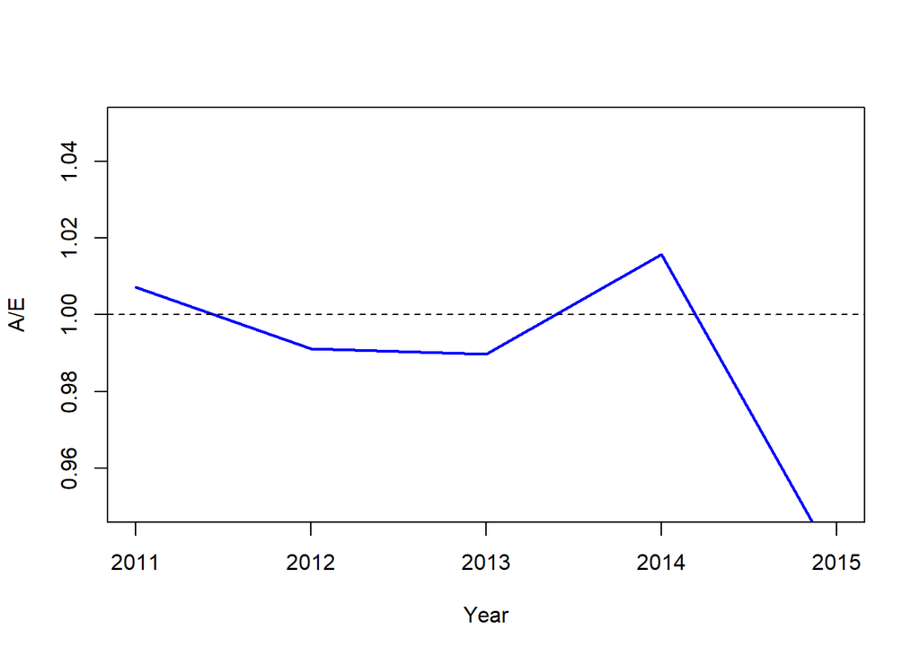

```r
year.plot.data <- heartattack %>%
  filter(Sample == "holdout") %>%
  group_by(Year) %>%
  summarize(AE.year = mean(outcome)/mean(Preds))

# Base R
plot(x = year.plot.data$Year,
     y = year.plot.data$AE.year,
     type = "l",
     lwd = 2,
     col = "blue",
     ylim = c(0.95, 1.05),
     xlab = "Year",
     ylab = "A/E")
abline(h = 1,
       lty = 2)
```

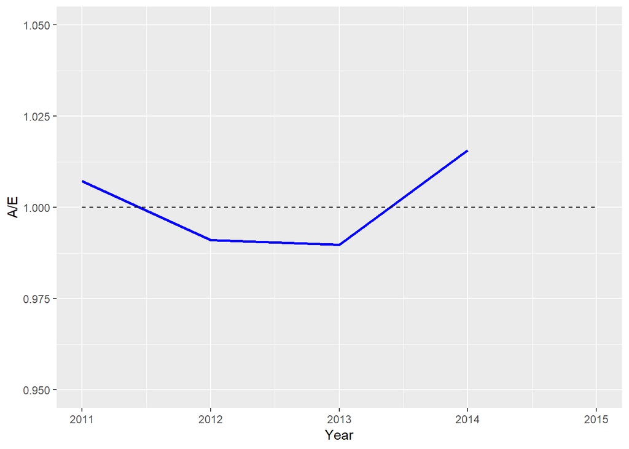

```r
# ggplot
year.plot.data %>%
  ggplot(aes(x = Year, y = AE.year)) +
  geom_line(color = "blue", size = 1) +
  geom_line(aes(y = 1), linetype = 2) +
  ylim(c(0.95, 1.05)) + ylab("A/E")
```

##### b) Across a categorical variable like “Race” (i.e. Race on the x-axis)

**The x-axis is discrete in this case, and we have to add a little extra code to each of the base-R and ggplot solutions.**

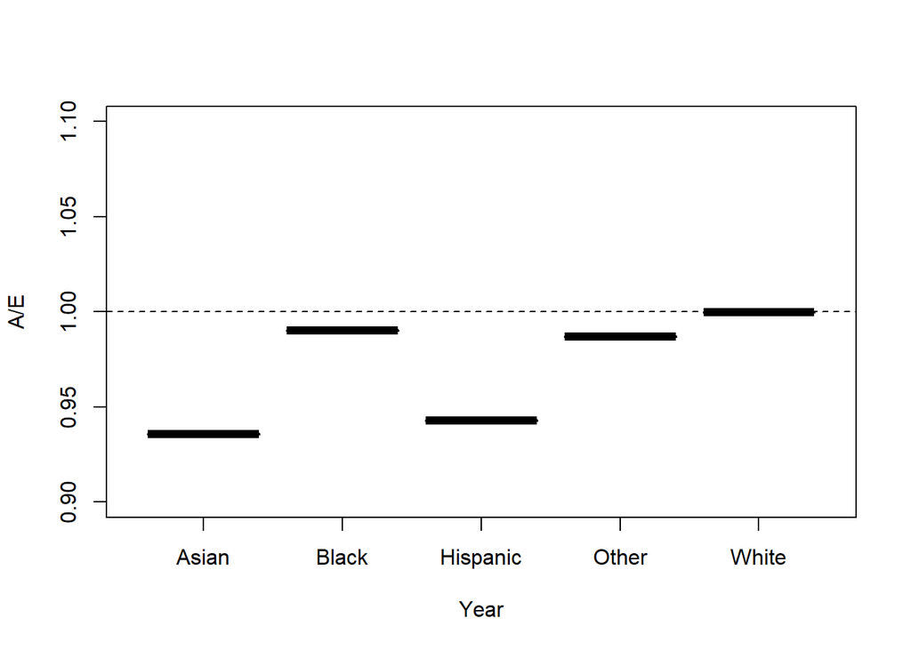

```r
race.plot.data <- heartattack %>%
  filter(Sample == "holdout") %>%
  group_by(Race) %>%
  summarize(AE.race = mean(outcome)/mean(Preds))

# Base-R
plot(x = factor(race.plot.data$Race),
     y = race.plot.data$AE.race,
     type = "l",
     lwd = 2,
     col = "blue",
     ylim = c(0.9, 1.1),
     xlab = "Year",
     ylab = "A/E")
abline(h = 1,
       lty = 2)
```

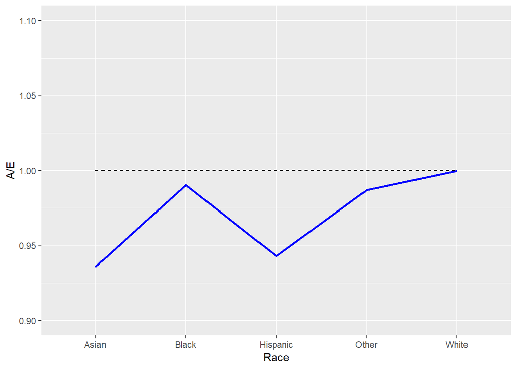

```r
# ggplot
race.plot.data %>%
  ggplot(aes(x = factor(Race), y = AE.race, group = 1)) +
  geom_line(color = "blue", size = 1) +
  geom_line(aes(y = 1), linetype = 2) +
  ylim(c(0.9, 1.1)) + ylab("A/E") +
  xlab("Race")
```

### 3) Calculate the AUC on the holdout data.

**We use the ROCR package to calculate the AUC. 58% is not particularly good, though beter than randomly guessing, which would lead to a 50% AUC.**

```r
auc.object <- prediction(heartattack$Preds[heartattack$Sample == "holdout"],
                         heartattack$outcome[heartattack$Sample == "holdout"])

performance(auc.object, "auc")@y.values[[1]]
```

```
## [1] 0.5837472
```

### 4) Extra: Create a second model and construct a two-way lift chart.

**Whether you look at the two-way lift chart or the AUC on the new model, there is not noticeable improvement. It seems we have added a lot of complexity to our model for no gain.**

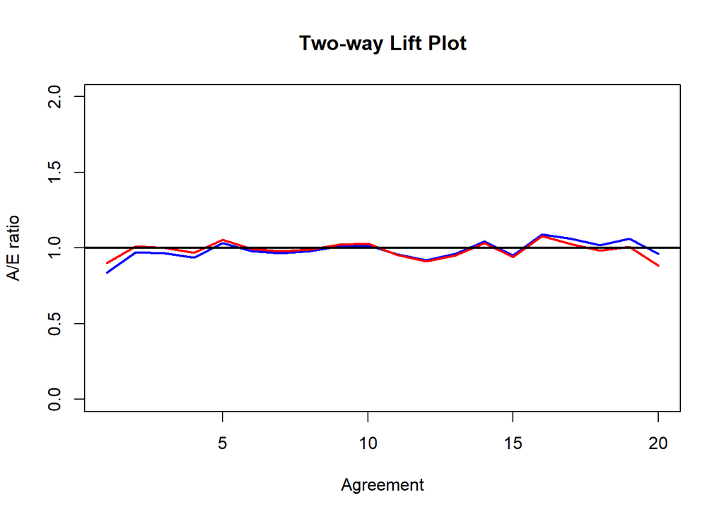

```r
# Fit new model with Region:Race interaction
logistic.model2 <- glm(outcome ~ Region*Race + Year + Age + Sex,
                       family = binomial(link = logit),
                       data = heartattack %>% filter(Sample == "training"), model = F,
                       x = F, y = F)

# Append new predictions
heartattack <- heartattack %>%
  mutate(Preds2 = predict(logistic.model2,
                          newdata = .,
                          type = "response"))

# Create two-way lift chart
two.way.plot.data <- heartattack %>%
  filter(Sample == "holdout") %>%
  group_by(Agreement = ntile(Preds2/Preds, 20)) %>%
  summarize(AE1 = mean(outcome)/mean(Preds),
            AE2 = mean(outcome)/mean(Preds2))

plot(two.way.plot.data$Agreement,
     two.way.plot.data$AE1,
     ylim = c(0,2),
     xlab = "Agreement",
     ylab = "A/E ratio",
     main = "Two-way Lift Plot",
     type = "l",
     lwd = 2,
     col = "blue")
lines(two.way.plot.data$Agreement,
      two.way.plot.data$AE2,
      lwd = 2,
      col = "red")
abline(h = 1, lwd = 2)
```

```r
# Test AUC
auc.object <- prediction(heartattack$Preds2[heartattack$Sample == "holdout"],
                         heartattack$outcome[heartattack$Sample == "holdout"])

performance(auc.object, "auc")@y.values[[1]]
```

```
## [1] 0.5841447
```